# Obtaining a full crypt morphology

Axel Almet

05 September, 2018

# Generalised-set up

We model the crypt as a planar, growing, inextensible elastic rod attached to an underlying foundation $\mathbf{f} = f\mathbf{e}_x + g\mathbf{e}_y$, the choice of which we will explore. Tissue growth is encapsulated by the growth stretch $\gamma$, modelling a local increase of the initial arc length $S_0$; that is,
$$\begin{align}
\gamma = \frac{\partial s}{\partial S_0}.
\end{align}$$
The equations describing geometric constraints and balance of linear and angular momentum are given by:
$$\begin{align}
&x' = \gamma\cos\theta,\\
&y' = \gamma\sin\theta,\\
&n_x' + \gamma f = 0,\\
&n_y' + \gamma g = 0,\\
&\theta' = E_b\gamma m,\\
&m' = \gamma(n_x\sin\theta - n_y\cos\theta).
\end{align}$$
For simplicity, we assume the rod is clamped horizontally at the boundaries:
$$\begin{align}
x(0) = 0, \qquad x(L_0) = 0, \qquad y(0) = y(L_0) = y_0, \qquad \theta(0) = \theta(L_0) = 0.
\end{align}$$

The parameter $L_0$ is the initial rod length, giving the horizontal interval of deformation for the crypt.

# What is the most appropriate foundation law?

Attached directly underneath the intestinal epithelium is the basement membrane, a thin, fibrous network of extracellular proteins. The basement membrane provides an anchoring on which the epithelial cells can migrate, as well as facilitating epithelial-mesenchymal communication. Underneath the basement membrane sits the lamina propria, a heterogeneous composition of mesenchymal cells. The lamina propria provides structural support between crypts, and also has been shown in recent years to provide extrinsic growth and differentiation factors, for example, the non-canonical Wnt5a and Bone Morphogenetic Proteins (BMPs) such as Grem1.

Mechanically, it is unclear what the best description for the basement membrane and stroma should be, in terms of the underlying rod foundation. In continuum models of the crypt, the basement membrane and stroma are often modelled by a constitutive law describing the bulk behaviour of the underlying attachments to the epithelium (Edwards and Chapman, 2007; Nelson et al., 2011; Nelson et al., 2013), although models that describe both explicitly do exist (Hannezo et al., 2011).

All foundations in this framework are modelled in the same manner. We the attachment of the rod centreline $\mathbf{r} = (x, y)$ to the (initial) foundation line $\pmb{\rho} = (p_x, p_y)$ as such:
$$\begin{align}
\mathbf{f} = \frac{\sigma}{\Delta}(\pmb{\rho} - \mathbf{r}) = \frac{\sigma}{\Delta}\left[(p_x - x)\mathbf{e}_x + (p_y - y)\mathbf{e}_y\right],
\end{align}$$

where $\Delta = \|\pmb{\rho} - \mathbf{r}\|$ measures the total strain undergone by the rod. The mechanical evolution of the foundation is thus described completely by the stress parameter $\sigma$ and the foundation shape $\pmb{\rho}$.

### Elastic foundation

The simplest choice for the underlying stroma is that of an elastic foundation, as used by Hannezo et al. (2011). A generalised elastic foundation description is given by
$$\begin{align}
\sigma = \gamma^{-1}h(\Delta), \qquad \pmb{\rho} = (S_0, 0).
\end{align}$$
Note the presence of the factor of $\gamma^{-1}$ to account for the absence of remodelling of the foundation. In the linear elastic case, we have $h(\Delta) \approx k\gamma^{-1}\Delta$, where $k$ represents the foundation stiffness. Consequently, the force balance equations are given by
$$\begin{align}
n_x' = k(x - S_0), \qquad n_y' = ky.
\end{align}$$

### Linear viscoelastic

When modelling linear viscoelasticity, we have two choices: a Kelvin-Voigt law or a Maxwell law. The latter has been the most popular choice for previous models.

In the case of Kelvin-Voigt viscoelasticity, stress is modelled to have simultaneous elastic and viscous contributions (a spring and dashpot in parallel):
$$\begin{align}
\sigma = \sigma_E + \sigma_V.
\end{align}$$
In our framework, we model the elastic contribution as $\sigma_E = k\Delta$, and the viscous contribution by $\sigma_V = \nu\dot{\Delta}$. After substitution and non-dimensionalisation, we have the following stress-strain law:
$$\begin{align}
\sigma = \Delta + \eta\dot{\Delta},
\end{align}$$
where $\eta$ describes the (non-dimensional) viscoelasticty of the foundation. Observe that the special case $\eta = 0$ gives the elastic foundation model. We model the foundation attachment to be unchanging, and given by $\pmb{\rho} = (S_0, 0)$. The linear momentum equations are now given by
$$\begin{align}
n_x' = k\gamma\frac{\sigma}{\Delta}(x - S_0), \qquad n_y' = k\gamma\frac{\sigma}{\Delta}y.
\end{align}$$
We can simplify the force balance further by assuming that horizontal displacement is dominated by vertical displacment, i.e. $|x - S_0| \ll |y|$. Then $\Delta \sim y$ and we have
$$\begin{align}
n_x' = 0, \quad n_y' = k\gamma\sigma, \qquad\mbox{ where }\qquad \sigma = y + \eta\dot{y}.
\end{align}$$
In the case of a Maxwell foundation, we describe strain contributions from an elastic and viscous component (in series):
$$\begin{align}
\Delta = \Delta_E + \Delta_V.
\end{align}$$
Differentiating the above law with respect to time and substituting the laws for the elastic and viscous contributions leads to the following after non-dimensionalisation:
$$\begin{align}
\dot{\sigma} - \dot{\Delta} + \eta\sigma = 0.
\end{align}$$
We note that setting $\eta = 0$ reduces the model to the elastic foundation, as was true for the Kelvin-Voigt model. The force balance equations are equivalent to the Kelvin-Voigt case in form:
$$\begin{align}
n_x' = k\gamma\frac{\sigma}{\Delta}(x - S_0), \qquad n_y' = k\gamma\frac{\sigma}{\Delta}y.
\end{align}$$
Applying the same approximation as previously, we obtain
$$\begin{align}
n_x' = 0, \quad n_y' = k\gamma \sigma, \qquad\mbox{ where }\qquad \dot{\sigma} - \dot{y} + \eta\sigma = 0.
\end{align}$$

### Remodelling foundation

Our final candidate is inspired by a model of seashell evolution (Chirat et al., 2013). Here, we take $\sigma = k\Delta$, and model the temporal evolution of $\pmb{\rho}$ by
$$\begin{align}
\dot{\pmb{\rho}} = \eta(\mathbf{r} - \pmb{\rho}), \qquad \pmb{\rho}(0) = (S_0, 0).
\end{align}$$
The force balance equations in this case are given by
$$\begin{align}
&n_x' = k\gamma (x - p_x), \quad\mbox{ where }\quad \dot{p}_x = \eta(x - p_x),\ p_x(0) = S_0;\\
&n_y' = k\gamma (y - p_y), \quad\mbox{ where }\quad \dot{p}_y = \eta(y - p_y), \ p_y(0) = 0.
\end{align}$$

This law describes the relaxation of the foundation to the current crypt shape, dependent on the relaxation rate $\eta$. As before, setting $\eta = 0$ recovers the elastic foundation model.

# Other types of relaxation

So far, we have only considered relaxation due to the evolution of foundation stresses or the foundation shape. However, it is also very possible that the relaxation of the epithelium itself—say, due to rearrangements of tight junctions and integrins—plays a role in the morphogenesis of the crypt. Mathematically speaking, this is equivalent to an evolution of the intrinsic curvature of the rod. We thus modify the moment-curvature relation above to account for an evolving intrinsic curvature $\hat{\kappa}$, as such:
$$\begin{align}
m = E_b(\theta'\gamma^{-1} - \hat{\kappa}),
\end{align}$$
where we note that the first term on the right hand side is equivalent to the current (growth) curvature, $\kappa = \frac{\partial\theta}{\partial s}$. The simplest law for the evolution of $\hat{\kappa}$ takes the following form:
$$\begin{align}
\frac{\partial\hat{\kappa}}{\partial t} = \chi(\kappa - \widehat{\kappa}).
\end{align}$$

# Results

In all simulations, we set growth to be homogeneous and increasing at a constant rate in time:
$$\begin{align}
\dot{\gamma} = 1,
\end{align}$$

and set the bending stiffness $E_b \equiv 1$ to be spatially homogeneous. The foundation stiffness is set to $k_f = 0.001$, while the cross-section of the rod is assumed to be rectangular, with height $h = 15 \mu\mathrm{m}$ and width $w = 10 \mu\mathrm{m}$, and the dimensional initial rod length is $L_0 = 125\mu\mathrm{m}$.

### Elastic foundation

The elastic foundation case is the simplest because there is no relaxation of neither the stresses nor the foundation shape. Hence, the shape of the rod is completely determined by two parameters in this model, the growth stretch $\gamma$ and the foundation stiffness $k$. Here is a typical growth evolution of the rod shape until self-contact.

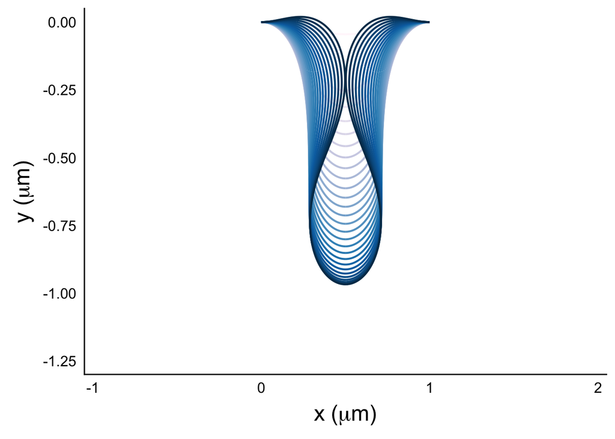

We can also plot the horizontal and vertical force components, $n_x$ and $n_y$, and the non-dimensional stress, $\sigma = \Delta$.

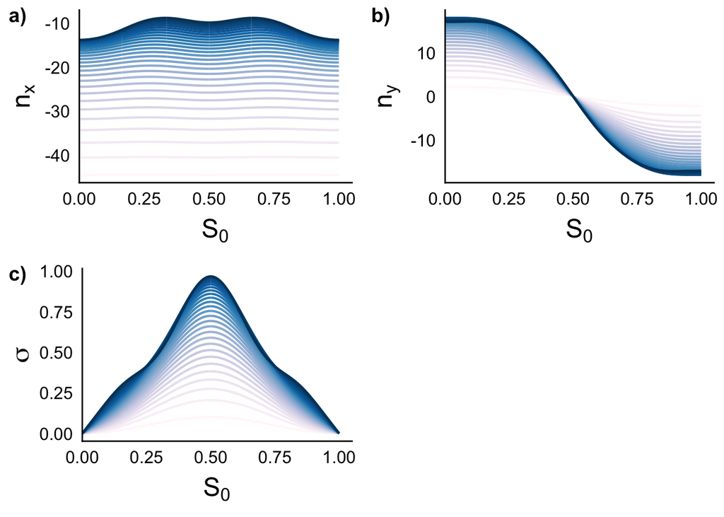

We see that non-uniformities develop in $n_x$ as $\gamma$ increases, as the post-buckled evolution relieves horizontal compression within the rod. Furthermore, observe that the stress becomes most pronounced at the tip of the invagination. This feature turns out to be common amongst all foundation models explored.

### Viscoelastic foundation

For a Maxwell foundation, we observe that the horizontal forces are effectively uniform for increasing $\gamma$, and the stress is once again most pronounced at the invagination tip. However, we do see that the stress decreases at later times, due to the rapid relaxation of $n_x$.

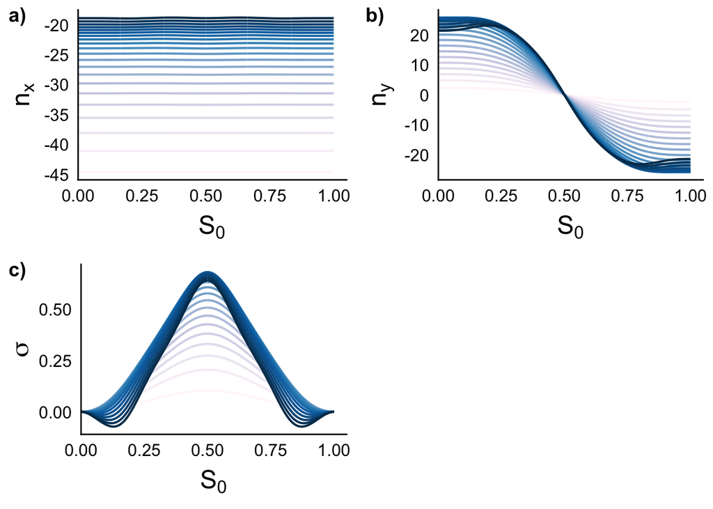

The uniformity of $n_x$ suggests that we can approximate the full viscoelastic law by a vertically-dominated law ($\Delta \sim y$). However, the plots show that the behaviour, at least in a morphological sense, is not the same for various values of $\eta$.

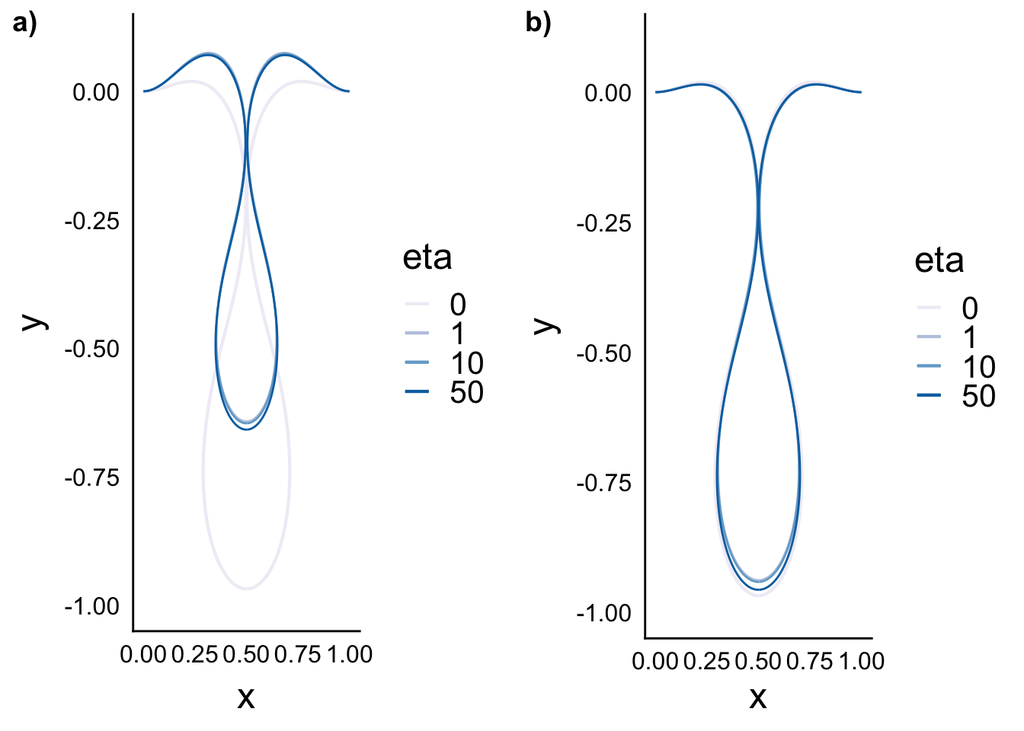

### Remodelling foundation

Below is the typical evolution for a rod attached a remodelling foundation.

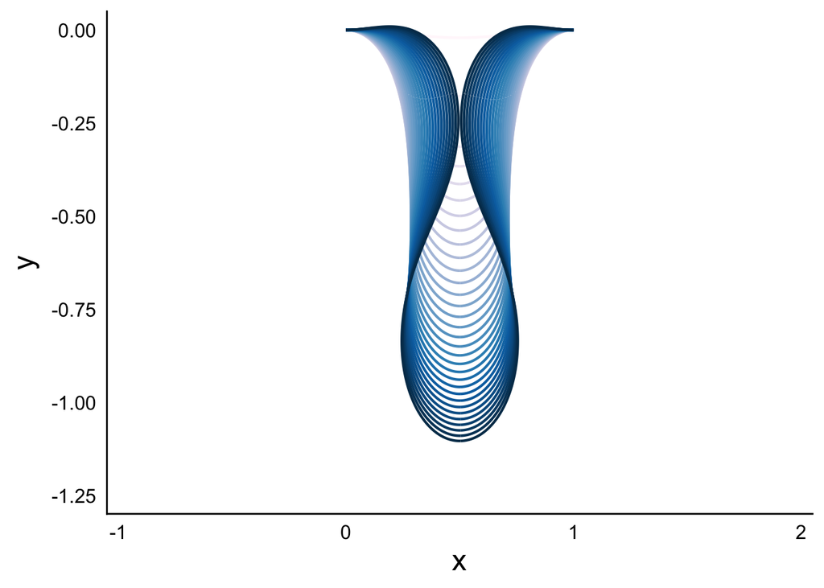

As expected, the stress profiles for a remodelling foundation are very similar to those for an elastic foundation, with the stress being most concentrated at the tip of the invagination.

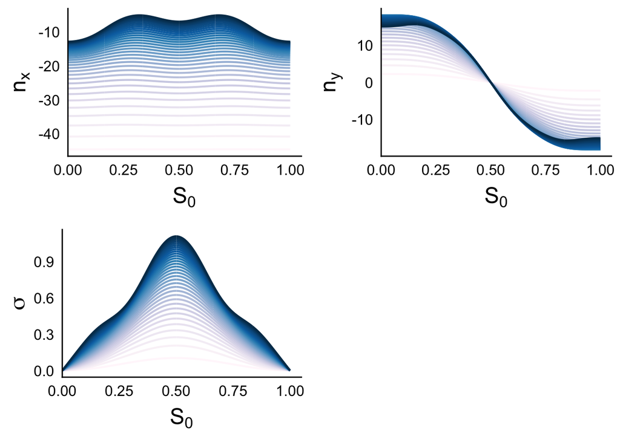

The parameter that is clearly of most interest is the foundation relaxation parameter $\eta$. Here, we plot the final, pre-self-contact shape for various values of $\eta$. Increasing $\eta$ has the two-fold effect of increasing both the invagination length, as well as the bulge width, effectively keeping the aspect ratio constant as $\eta$ increases.

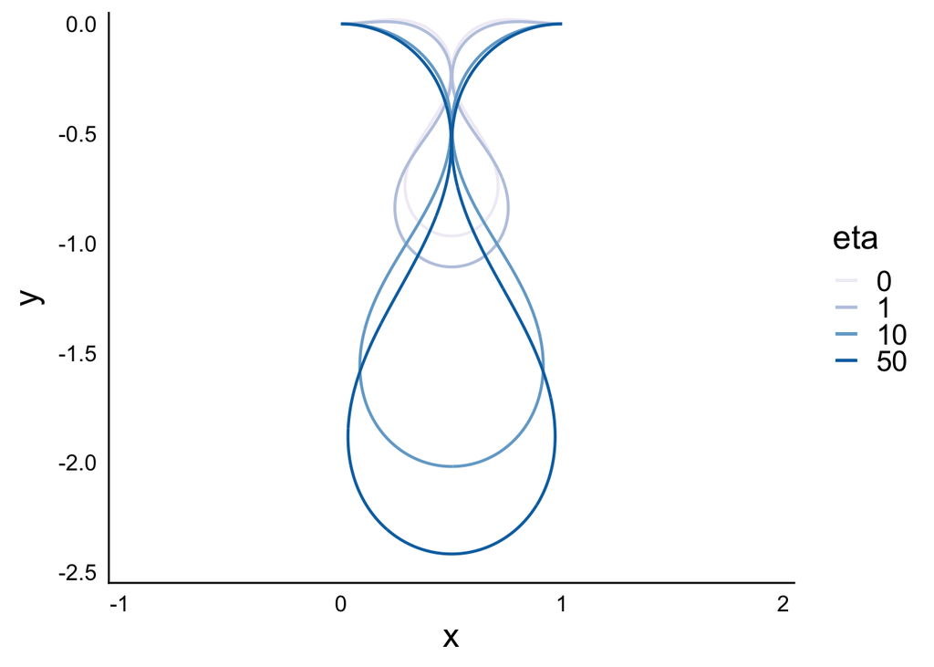

### Curvature remodelling

We now examine the effect of a remodelling intrinsic curvature, dictated by the remodelling parameter $\chi$. We first test the effect of curvature relaxation on a static, elastic foundation. As we increase $\chi$, we decrease the bending energy and hence the bending moment. This makes it energetically less favourable for the rod to invaginate, as it grows.

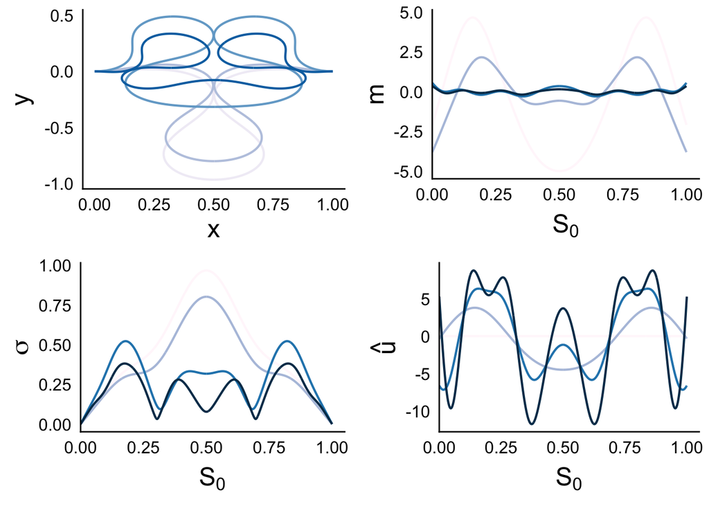

In comparison, for a remodelling foundation, the results appear to be largely similar. For a non-zero value of $\eta$, the deepened invagination negates some of the effect of increased $\chi$.

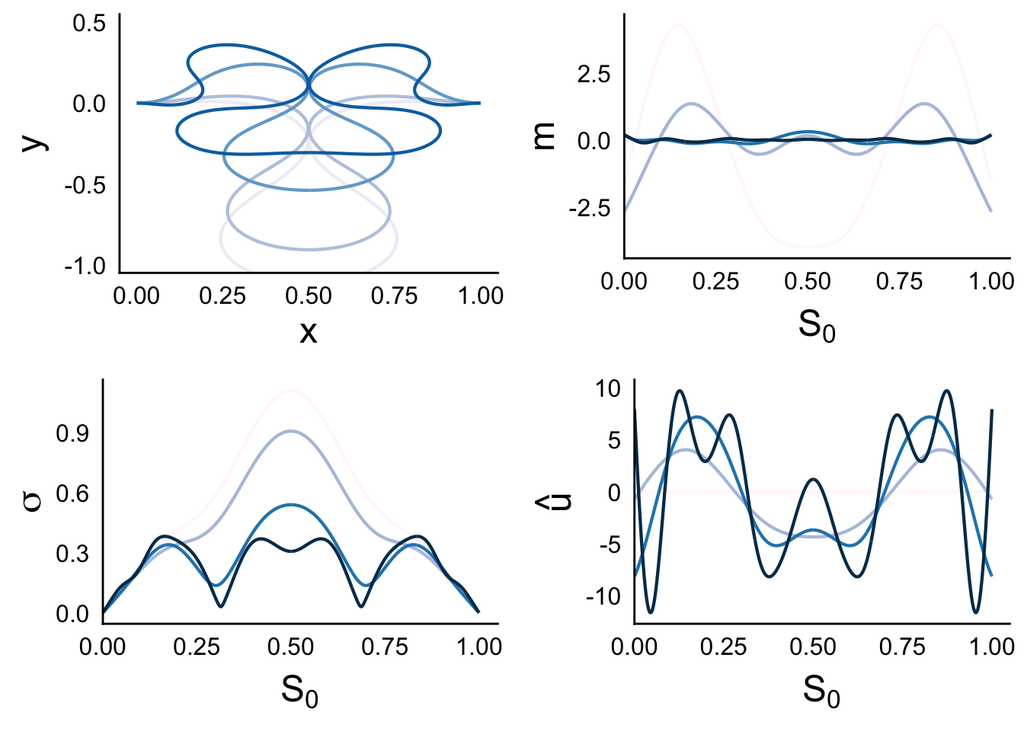

# Conclusions

Of all the foundation laws considered, the ‘plastic’ remodelling foundation law appears to have the greatest promise in producing an invagination length akin to that of the crypt (a ratio of up to five-to-one, in terms of length of crypt to width of deformation). However, in the case of homogeneous growth and stiffness, we note that this law maintains a constant aspect ratio for all values of the relaxation parameter $\eta$. Therefore, it makes sense to couple this foundation law with heterogeneities in bending stiffness, say.

One interesting feature that arose out of all foundation models was the concentration of stress at the tip of the invaginations. Specialising this model to that of a crypt, we note that the bending stiffness would be softest in this region of the rod. Furthermore, in the crypt, initial growth is concentrated about the invagination tip, but as the crypt matures in structure, transit-amplifying cells that sit above the crypt base become the dominant driver of cell population. One hypothesis that could be drawn from this is that the mechanical stress that develops at the invagination tip begins to inhibit proliferation in the base, allowing the transit-amplifying cells to continue proliferating while stem cell proliferation slows down. This also may in part explain why a number of stem cells within the base appear to be in a quiescent, ‘unlicensed’ state (Carroll et al., 2018). This suggests the following, simple mechanochemical law:
$$\begin{align}
\frac{\dot{\gamma}}{\gamma} = W(s) + \mu(\sigma^* - \sigma),
\end{align}$$

where $W(s)$ denotes the observable concentration of Wnt signalling (defined with respect to the current arclength parameter $s$).